# Epidemic Spreading: SIR Model with Vital Dynamics

Letitia Kernschmidt

# 1 Example Network: Dolphins

The example network is a social network of bottlenose dolphins. The nodes are the bottlenose dolphins (genus Tursiops) of a bottlenose dolphin community living off Doubtful Sound, a fjord in New Zealand (spelled fiord in New Zealand). An edge indicates a frequent association. The dolphins were observed between 1994 and 2001.

- Type: Undirected, unweighted
- Vertices (Dolphins): 62
- Edges (Associations): 159
- Category: Animal

*Source*: http://konect.uni-koblenz.de/networks/dolphins

Note that this network was selected, because it has such a small size that it can be easily plotted for visualization purposes.

**Epidemic Parameters**  
For visualization purposes, both the infection rate as well as the recovery rate are set quite high. For real life epidemic spreading simulations, these rates have to be adjusted accordingly.

# 2 SIR Model

The SIR-Model (Susceptible-Infected-Recovered Model) is an extension of the SI-Model and is used to model infections from which infected individuals recover with immunity (e.g. most diseases transmitted by viral parasites). It consists of the three classes susceptible, infected and recovered. Whereas the susceptible and the infected classes are equal to the ones of the SI-Model, individuals in the recovered class have recovered from the disease with immunity and cannot transmit the disease to any other individual. Infected individuals are assumed to recover (or die) from the disease at a constant average recovery rate gamma. Hence, the average duration of infection is equal to 1/gamma.

# 3 Vital Dynamics

In This model, we assume that vertices can die and be newly born in each time step. However, in this tutorial we assume that the population stays constant, i.e. that the births and the deaths are always equal. Newly born vertices are susceptible.

### 3.0.1 Preparation

Before starting with the analysis, RStudio and ImageMagick need to be installed.  
**IMPORTANT**: When installing ImageMagick, the option “Install legacy components (convert.exe etc)” MUST be selected.

- **RStudio** can be downloaded here: https://www.rstudio.com/products/rstudio/download3/
- **ImageMagick** can be downloaded here: http://www.imagemagick.org/script/binary-releases.php

### 3.0.2 Loading the Network Dataset

```r
# Load the igraph, the animation, and the xtable package (needs to be installed in R before use)
library(igraph)
library(animation)
library(xtable)

# Set your working directory - this is especially important if you want to save the animation
# setwd("INSERT HERE YOUR WORKING DIRECTORY")
```

```r
# Load a network from a .csv file
dat=read.csv(file.choose(),header=TRUE)
el=as.matrix(dat)
el[,1]=as.character(el[,1])
el[,2]=as.character(el[,2])
n=graph.edgelist(el,directed=FALSE)
```

```r
# Set N as the number of vertices
N = vcount(n)

# Set deg as the degree distribution of the graph and round the result to 2 digits
# Based on the degree distribution, the new born vertex receives a number of new edges
deg = round(degree.distribution(n), digits = 2)

# Set init_inf as the number of initially infected vertices
init_inf = 5

# Set simlength as the number of timesteps per simulation
simlength = 100

# Set simnumber as the number of simulations
simnumber = 1

# Set beta as the infection rate
beta = 0.3

# Set gamma as the recovery rate
gamma = 0.2

# Set mu as the death/birth rate - Since the size of the population is to remain constant,
# this rate must be equal for both the death rate and the birth rate
mu = 0.1

# Set TRUE if the spreading shall be plotted
# This makes only sense if the graph is reasonably small
plot.spread = TRUE

# Set to FALSE if the vertices cannot recover from timestep 0 to timestep 1
recovery.wait = FALSE

links = as_edgelist(n, names = FALSE)

infdata_sum = list()
susdata_sum = list()
recdata_sum = list()
incidence_sum = list()
```

### 3.0.3 Simulation

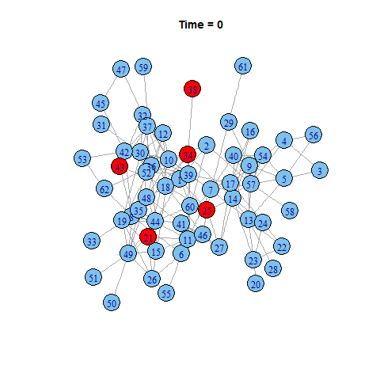

```r
######### SIMULATION #########

for (j in 1:simnumber){

  #### Infected
  # The infected vertices are selected randomly by "sample"
  # Initially all vertices are set to FALSE in a logical vector
  # Those vertices which are selected to be infected are set to TRUE
  infected = logical(N)
  patientzero = sample(N,init_inf)
  infected[patientzero] = TRUE

  #### Susceptible
  # The number of susceptible vertices is equal to the total number of vertices
  # minus the number of infected vertices (only initially, because there are no recovered vertices
  # at the beginning)
  susceptible = N - sum(infected==TRUE, na.rm = TRUE)

  #### Recovered
  # Recovered vertices are set to NA
  rec_na = is.na(infected)

  #### Death and Birth
  # Initally all vertices are set to FALSE with respect to death/birth, meaning that at
  # timestep 0 every vertex is alive
  death_birth = logical(N)

  #### Lists to save the simulation results
  infdata = list(sum(infected==TRUE, na.rm = TRUE))
  susdata = list(susceptible)
  recdata = list(sum(rec_na))
  incidence = list()

  ################# PLOT SPREAD #######################

  if (plot.spread) {
    network.i = graph.edgelist(links, directed=FALSE)
    fixlayout = layout.kamada.kawai(network.i)
    node.colour = rep("SkyBlue2",N)
    node.colour[patientzero] = "red"
    png(paste("sim", 000, ".png", sep = "."))
    plot(network.i,layout=fixlayout, main="Time = 0", vertex.color=node.colour)
    dev.off()
  }

  ################ PADDING ###################

  pad_int = function(n,scale){
    out_string = paste(10*scale + n,sep='')
    out_string = substr(out_string,2,nchar(out_string))
    return(out_string)
  }

  ##################################################################

  for (i in 1:simlength) {
    #### Death and Birth is reset for every time step
    death_birth = logical(N)

    # Starting from timestep 1 to timestep 2
    if (recovery.wait==FALSE || i > 1){

      # Select the infected vertices
      infected.vertices = which(infected)

      # Select those vertices which will recover during this timestep using binomial distribution
      recover = rbinom(sum(infected==TRUE, na.rm = TRUE),1,gamma)
      # Those vertices for which the rbinom function results in 1 are set to be recovering
      recover.vertices = infected.vertices[recover==1]
      #node.colour[recover.vertices] = "green"
      # These vertices are set to NA in the logical vector
      infected[recover.vertices] = NA
    }

    discordant.links = which(xor(infected[links[,1]],infected[links[,2]]))
    transmit = rbinom(length(discordant.links),1,beta)
    transmitter.links = discordant.links[transmit==1]
    nodes.of.transmitter.links = unique(as.vector(links[transmitter.links,1:2]))
    infected[nodes.of.transmitter.links] = TRUE

    # Select those vertices, which will die during this timestep
    # Vertices from all compartments can die, hence the rbinom function is applied to N (all vertices)
    dead = rbinom(N,1,mu)
    death_birth[dead==1] = TRUE

    # Select all edges which are connected to the dead vertices
    dead.edges = which(xor(death_birth[links[,1]],death_birth[links[,2]]))

    # Delete the edges, which are connected to the dead vertices
    n = delete.edges(n, dead.edges)

    # Since the dead vertices are replaces by newly born vertices
    # in order to keep the number of vertices constant
    # all dead vertices are set back to being susceptible
    infected[dead==1] = FALSE

    # Select the new degree for the new born vertex from the degree distribution of the graph
    sam_vec = seq(from = 0, to = (length(deg) - 1), by = 1)
    new_degree = sample(sam_vec,sum(death_birth),prob = deg, replace = TRUE)

    # The vertices that die during this timestep are selected
    dead.vertices = which(death_birth)

    # For each "dead" vertex a new vertex is "born"
    # The new vertex has a degree as described above and respective edges are added
    for(x in 1:(length(dead.vertices))){
      for(y in 1:new_degree[x]) {
        n = add.edges(n, c(dead.vertices[x],sample(N,1)))
      }
    }

    # In order to avoid that the added edges result in loops or multi-edges
    # the simplify function is applied
    n = simplify(n, remove.multiple = TRUE, remove.loops = TRUE)

    # In case of dynamics, the edgelist must be constantly updated
    links = as_edgelist(n, names = FALSE)

    infdata[[i+1]] = sum(infected==TRUE, na.rm = TRUE)
    susdata[[i+1]] = N - sum(infected==TRUE, na.rm = TRUE) - sum(is.na(infected))
    recdata[[i+1]] = sum(is.na(infected))

    incidence[[i]]=susdata[[i]] - susdata[[i+1]]
    if (plot.spread) {
      network.i = graph.edgelist(links, directed=FALSE)
      node.colour[infected] = "red"
      node.colour[death_birth] = "SkyBlue2"
      node.colour[recover.vertices] = "green"
      padded = pad_int(i,100)
      png(paste("sim",padded,".png", sep=""))
      plot(network.i,layout = fixlayout, main = paste("Time =", i), vertex.color = node.colour)
    }
    # Remeber to set dev.off() into comments when setting plot.spred to FALSE!
    dev.off()
  }
  infdata_sum[[j]] = infdata
  susdata_sum[[j]] = susdata
  recdata_sum[[j]] = recdata
  incidence_sum[[j]] = incidence
}

shell("convert -delay 100 *.png SimulationSIRVitalConstant.gif")
```

### 3.0.4 Prevalence

Since vertices constantly die and are newly reborn as susceptible vertices, the epidemic does not always die out as it is the case for SIR epidemics without vital dynamics. In fact, after an initial spread, the number of infected vertices mostly oscillates around an equilibrium. However, if all vertices that are infected die before transmitting the disease, the epidemic might still die out.

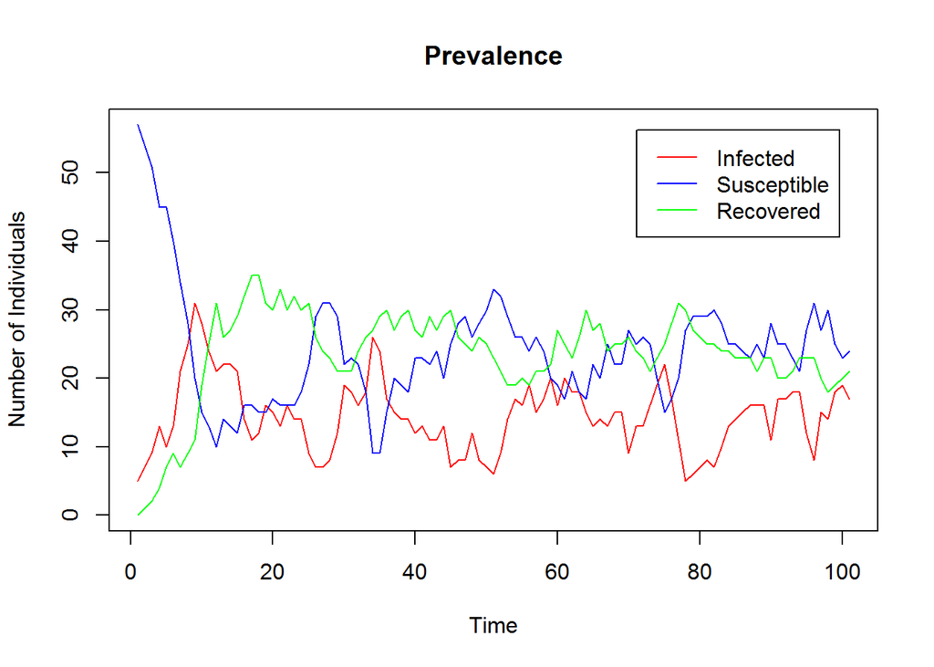

```r
infdata_table = as.data.frame(do.call(rbind,infdata_sum))
colnames(infdata_table) = paste("Time", 0:simlength)
rownames(infdata_table) = paste("Sim", 1:simnumber)
infdata_table = as.matrix(infdata_table)

susdata_table = as.data.frame(do.call(rbind,susdata_sum))
colnames(susdata_table) = paste("Time", 0:simlength)
rownames(susdata_table) = paste("Sim", 1:simnumber)
susdata_table <- as.matrix(susdata_table)

# The same procedure as above must be repeated for the recdata_sum list
recdata_table = as.data.frame(do.call(rbind,recdata_sum))
colnames(recdata_table) = paste("Time", 0:simlength)
rownames(recdata_table) = paste("Sim", 1:simnumber)
recdata_table = as.matrix(recdata_table)

# In order to plot all three results, i.e. the susceptible data AND the infected data AND the recovered data into one plot, all three matrices are combined into one matrix
combined = rbind(infdata_table, susdata_table, recdata_table)

matplot(t(combined), type="l", lty = 1, col = ifelse(combined[,c("Time 0")] == 0, "green", ifelse(combined[,c("Time 0")] > init_inf, "blue", "red")), xlab = "Time", ylab = "Number of Individuals")
title(main = "Prevalence")
legend("topright", inset = .05, legend=c("Infected", "Susceptible", "Recovered"), col=c("red","blue", "green"), lty = 1:1)
```

### 3.0.5 Incidence

Similar to the prevalence, the number of newly infected vertices oscillates around an equilibrium in case of vital dynamics.

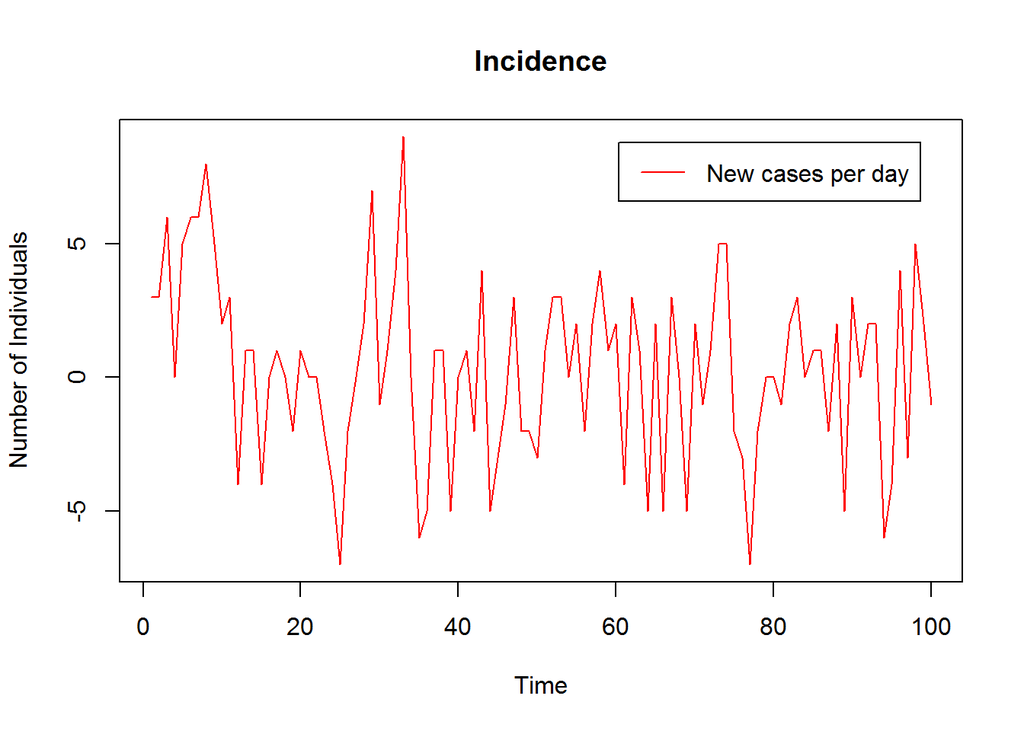

```r
incidence_table = as.data.frame(do.call(rbind,incidence_sum))
colnames(incidence_table) = paste("Time", 1:simlength)
rownames(incidence_table) = paste("Sim", 1:simnumber)

incidence_table = xtable(incidence_table, digits = 0, caption="Incidence")
print(incidence_table, type="html", file="IncidenceTableGnutella.html")

incidence_table = as.matrix(incidence_table)

matplot(t(incidence_table), type="l", lty = 1, col = "red", xlab = "Time", ylab = "Number of Individuals")
title(main = "Incidence")
legend("topright", inset = .05, legend=c("New cases per day"), col=c("red"), lty = 1)
```